# Midterm 2 Corrections

Vaishnavi Maganti

2026-03-05

## Load the libraries

```r
library(tidyverse)
library(janitor)
library(naniar)
library(ggmap)
library(lubridate)
library(shiny)
```

```r
register_stadiamaps("e90f7f28-b515-4bb7-a0e1-807ba10a7ee8", write = FALSE)
```

```r
getwd()
```

```
## [1] "/Users/magantiv/Desktop/clone_repository_github/BIS15L_W26_vmaganti"
```

## Load the data

Run the code chunk below to load the data, clean the names, and do some tidying.

```r
polar_bears <-
  read_csv("midterm2/data/polarBear_serumUreaCreatinine_beaufortChukchi_rode.csv") %>%
  clean_names() %>%
  select(-den_method, -no_cubs, -cub_age) %>%
  filter(age_class==c("A", "S")) %>%
  mutate(sex=toupper(sex),
         age_class=toupper(age_class))
```

### Question 2:

#### My Answer:

```r
polar_bears %>%
summarize(across(everything(), ~ sum(is.na(.))))
```

```
## # A tibble: 1 × 11
##   bear_id capture_date  popn   sex age_class mating denning   lat  long
##     <int>        <int> <int> <int>     <int>  <int>   <int> <int> <int>
## 1       0            0     0     0         0      0       0     0     0
## # ℹ 2 more variables: urea_nitrogen <int>, creatinine <int>
```

```r
polar_bears %>%
summarize(across(everything(), ~ sum(.==-999)))
```

```
## # A tibble: 1 × 11
##   bear_id capture_date  popn   sex age_class mating denning   lat  long
##     <int>        <int> <int> <int>     <int>  <int>   <int> <int> <int>
## 1       0            0     0     0         0      0       0     0     0
## # ℹ 2 more variables: urea_nitrogen <int>, creatinine <int>
```

```r
polar_bears_no_nas <- polar_bears %>%
  replace_with_na_all(condition = ~.x == -999) %>%
  miss_var_summary()
polar_bears_no_nas
```

```
## # A tibble: 11 × 3
##    variable      n_miss pct_miss
##    <chr>          <int>    <num>
##  1 bear_id            0        0
##  2 capture_date       0        0
##  3 popn               0        0
##  4 sex                0        0
##  5 age_class          0        0
##  6 mating             0        0
##  7 denning            0        0
##  8 lat                0        0
##  9 long               0        0
## 10 urea_nitrogen      0        0
## 11 creatinine         0        0
```

##### My Mistake:

I realized that I initially just summarized NA values and -999 values but didn’t properly replace any of those values with actual NA values and visualize the missing data.

##### Correction:

I used replace_with_na_all() to convert the values to NA and summarized missing values with miss_var_summary(). I also visualized the missing values before and after cleaning with the naniar package.

### Corrected Question 2

```r
summary(polar_bears)
```

```
##     bear_id       capture_date            popn               sex
##  Min.   :  697   Min.   :1983-04-23   Length:519         Length:519
##  1st Qu.:20166   1st Qu.:2000-04-10   Class :character   Class :character
##  Median :20705   Median :2008-04-12   Mode  :character   Mode  :character
##  Mean   :18040   Mean   :2004-07-02
##  3rd Qu.:21220   3rd Qu.:2011-03-31
##  Max.   :99990   Max.   :2016-04-22
##   age_class            mating            denning               lat
##  Length:519         Length:519         Length:519         Min.   :62.46
##  Class :character   Class :character   Class :character   1st Qu.:68.11
##  Mode  :character   Mode  :character   Mode  :character   Median :70.53
##                                                           Mean   :69.86
##                                                           3rd Qu.:71.00
##                                                           Max.   :72.70
##       long        urea_nitrogen     creatinine
##  Min.   :-172.2   Min.   : 1.00   Min.   :0.350
##  1st Qu.:-165.2   1st Qu.: 6.00   1st Qu.:0.850
##  Median :-150.7   Median :11.00   Median :1.050
##  Mean   :-153.7   Mean   :15.13   Mean   :1.079
##  3rd Qu.:-146.5   3rd Qu.:21.25   3rd Qu.:1.285
##  Max.   :-134.8   Max.   :69.00   Max.   :2.350
```

```r
polar_bears %>%
  summarize(across(everything(), ~sum(is.na(.))))
```

```
## # A tibble: 1 × 11
##   bear_id capture_date  popn   sex age_class mating denning   lat  long
##     <int>        <int> <int> <int>     <int>  <int>   <int> <int> <int>
## 1       0            0     0     0         0      0       0     0     0
## # ℹ 2 more variables: urea_nitrogen <int>, creatinine <int>
```

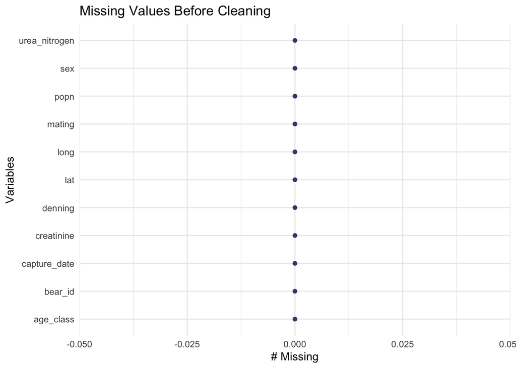

```r
gg_miss_var(polar_bears) +
labs(title = "Missing Values Before Cleaning")
```

```r
polar_bears_no_nas <- polar_bears %>%
  replace_with_na_all(condition = ~ .x == -999)
```

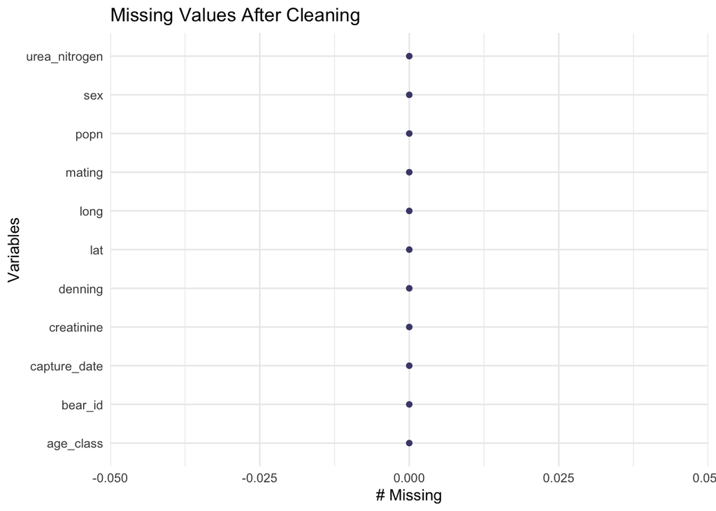

```r
gg_miss_var(polar_bears_no_nas) +
labs(title = "Missing Values After Cleaning")
```

### Question 4:

#### My Answer:

```r
#polar_bears <- polar_bears %>%
#separate(capture_date, c("year", "month", "day")) %>%
#count(year) %>%
#ggplot(mapping=aes(x=year, y = n)) +
#geom_line(na.rm = T, color = "pink") +
#geom_point(shape = 3) +
  #labs(title="Bears Sampled each year for Both Populations",
       #x="Population",
       #y="Number of Bears Sampled")
```

##### My Mistake:

I was not able to properly extract the year from the capture_date and I also did not group by population, so the plot didn’t run/correctly show sampling trends per population, which is why the code has also been commented out.

##### Correction:

I separated capture_date into year/month/day, grouped by year and population, and plotted lines and points for each of the bear populations using the polar_bears_no_nas data I had cleaned from my corrected answer to Question 2.

### Corrected Question 4

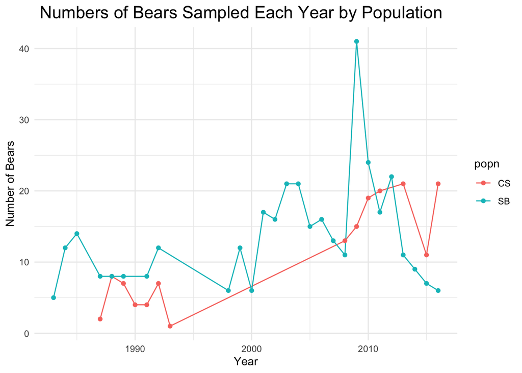

```r
polar_bears_no_nas <- polar_bears_no_nas %>%
  separate(capture_date, into = c("year", "month", "day"), sep = "-", remove = F)

polar_bears_no_nas %>%
  count(popn, year) %>%
  ggplot(aes(x = as.numeric(year), y = n, color = popn)) +
  geom_line() +
  geom_point() +
  labs(title = "Numbers of Bears Sampled Each Year by Population",
       x = "Year",
       y = "Number of Bears") +
  theme_minimal() +
  theme(plot.title=element_text(size=rel(1.5), hjust = 0.27))
```

### Question 7

#### My Answer:

```r
#fasting <- polar_bears %>%
  #mutate(fasting = case_when(
    #un_creat_ratio <= 10 ~ "fasting",
    #TRUE ~ NA_character_
  #)) %>%
  # drop_na(fasting)
#fasting
```

##### My Mistake:

I used case_when() but then dropped all the non-fasting bears with drop_na(fasting), so the variable was incomplete. Because of this, the non-fasting category was missing as well. I also created a new obkect fasting instead of properly updating the polar_bears_no_nas data set.

##### Correction:

I used mutate() on polar_bears_no_nas and created a fasting variable that is complete with “fasting” and “non-fasting” labels for all the rows, without dropping any data.

### Corrected Question 7

```r
polar_bears_no_nas <- polar_bears_no_nas %>%
  mutate(un_creat_ratio = (0.466 * urea_nitrogen)/ creatinine,
         fasting = case_when(
           un_creat_ratio <= 10 ~ "fasting",
           TRUE ~ "not_fasting"
         ))
```

### Question 8

#### My Answer:

```r
#polar_bears %>%
 # select(year, population, fasting) %>%
  #filter(fasting = "fasting") %>%
  #group_by(year) %>%
 #count(popn) %>%
 #ggplot(mapping = aes(x=year)) +
  #geom_bar(fill = popn, position = "dodge") +
  #labs(title = "The Number of Fasting Bears by Population Type by Year",
       #x = "Year",
       #y = "Count")
```

##### My Mistake:

I used filter(fasting = “fasting”) instead of ==, so the filter didn’t work correctly, and this question was also incorrect due to my work for Question 7 being incorrect. I also did not properly group by both year and population, and mapped the fill command incorrectly, so the plot ultimately failed to show the number of fasting bears per year AND population.

### Corrected Question 8

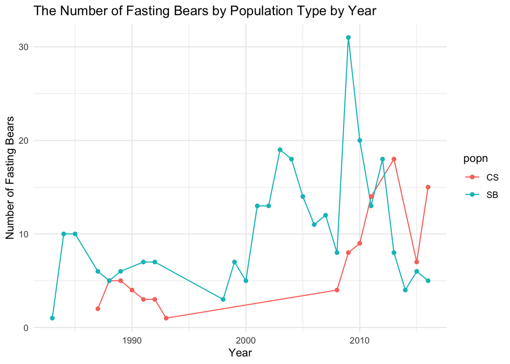

```r
polar_bears_no_nas %>%
  filter(fasting == "fasting") %>%
  group_by(year, popn) %>%
  summarize(n = n(), .groups = "drop") %>%
  ggplot(aes(x= as.numeric(year), y = n, color = popn)) +
  geom_line() +
  geom_point() +
  labs(title = "The Number of Fasting Bears by Population Type by Year",
       x = "Year",
       y = "Number of Fasting Bears") +
  theme_minimal()
```

### Question 9

#### My Answer:

```r
#bearslong <- polar_bears %>%
  #select(long)
#bearslat <- polar_bears %>%
  #select(lat) %>%
  #bearsbox <- make_bbox(long, bearslat, f = 0.03)
#bearsmap <- get_stadiamap(bearsbox, maptype = "stamen terrain", zoom = 5, color = "blue", alpha = 0.8)
#ggmap(bearsmap)
```

##### My Mistake:

I made tibbles instead of vectors that are numeric for make_bbox(), so the bounding box didn’t work properly. I also didn’t plot the points colored by population, so the map didn’t show which bears belonged to which population.

##### Correction:

I converted latitude and longitude to numeric vectors and then created a proper bounding box. I then also made a static map with get_stadiamap() and plotted the bear locations with geom_point() colored by population, which shows the distribution clearly.

### Corrected Question 9

```r
polar_bears_no_nas %>%
  select(lat, long) %>%
summary()
```

```
##       lat             long
##  Min.   :62.46   Min.   :-172.2
##  1st Qu.:68.11   1st Qu.:-165.2
##  Median :70.53   Median :-150.7
##  Mean   :69.86   Mean   :-153.7
##  3rd Qu.:71.00   3rd Qu.:-146.5
##  Max.   :72.70   Max.   :-134.8
```

```r
lat <- c(62.46, 72.70)
long <- c(-172.2, -134.8)
bbox <- make_bbox(long, lat, f = 0.03)
```

```r
bears_map <- get_stadiamap(bbox, maptype = "stamen_terrain", zoom = 5)
```

```
## ℹ © Stadia Maps © Stamen Design © OpenMapTiles © OpenStreetMap contributors.
```

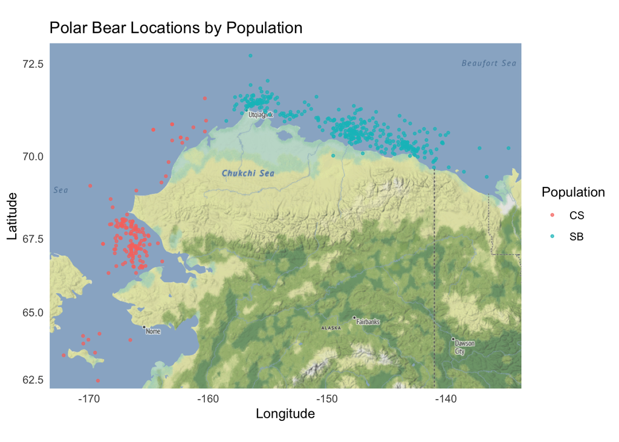

```r
ggmap(bears_map) +
  geom_point(
    data=polar_bears_no_nas,
    aes(x = long, y = lat, color = popn),
    size = 0.8,
    alpha = 0.7) +
  labs(title = "Polar Bear Locations by Population",
       x = "Longitude",
       y = "Latitude",
       color = "Population") +
  theme_minimal()
```

### Question 10

#### My Answer:

```r
#library(shiny)

#ui <- fluidPage(
  #selectInput("Fill",
              #"Select Fill",
              #choices = c("sex", "mating", "age_class", "denning", #"fasting"),
              #selected = "mating"),
   #plotOutput("plot", width = "600px", height = "500px")
#)

#server <- function(input, output, session) {
  #output$plot <- renderPlot({

    #polar_bears %>%
      #filter(popn == input$x) %>%
      # ggplot(aes(x=sex, fill = sex)) +
       #geom_bar(alpha = 0.8, color = "black") +
       #labs(x="Sex", y = NULL) +
       #theme_minimal()
#}

#shinyApp(ui, server)
```

##### My Mistake:

I filtered using input$x, which does not exist, and I also used a bar plot of sex instead of plotting the creatinine ratio. The app therefore did not result in users being able to choose the fill variable, which then led to inconsistencies with the rest of the problem.

##### Correction:

I created a Shiny app with a boxplot of un_creat_ratio by population and then let users select the fill variable by sex, mating, age_class, denning, or fasting. This would also allow for the range of values for both population sto be shown and to let the person using the app to choose a variable by grouping.

### Corrected Question 10

```r
library(shiny)

ui <- fluidPage(
  selectInput("Fill",
              "Select Fill Variable",
              choices = c("sex", "mating", "age_class", "denning", "fasting"), selected = "mating"),
  plotOutput("plot", width = "600px", height = "500px")
)

server <- function(input, output, session) {

  output$plot <- renderPlot({
    ggplot(polar_bears_no_nas, aes(x = popn, y = un_creat_ratio, fill = .data[[input$Fill]])) +
      geom_boxplot() +
      labs(title = "Distribution of UN/Creatinine Ratio by Population",
           x = "Population",
           y = "UN/Creatinine Ratio",
           fill = input$Fill) +
      theme_minimal()


  })

}

shinyApp(ui, server)
```